# Creating beautiful tables in R with {gt} - 2 Fancy stuff / Eye catchers

In this chapter, we’re going to learn how to add fancy elements like plots, icon and images to `{gt}` tables. We’re going to start this chapter by using a selection of the `gapminder` data set from `{gapminder}`.

```r
library(tidyverse)
library(gt)
gapminder_data <- gapminder::gapminder |>
  janitor::clean_names() |>
  select(continent, country, year, life_exp) |>
  mutate(
    year = as.character(year),
    # Year is really categorical with numeric labels
    country = as.character(country)
  )
gapminder_data
## # A tibble: 1,704 × 4
##    continent country     year  life_exp
##    <fct>     <chr>       <chr>    <dbl>
##  1 Asia      Afghanistan 1952      28.8
##  2 Asia      Afghanistan 1957      30.3
##  3 Asia      Afghanistan 1962      32.0
##  4 Asia      Afghanistan 1967      34.0
##  5 Asia      Afghanistan 1972      36.1
##  6 Asia      Afghanistan 1977      38.4
##  7 Asia      Afghanistan 1982      39.9
##  8 Asia      Afghanistan 1987      40.8
##  9 Asia      Afghanistan 1992      41.7
## 10 Asia      Afghanistan 1997      41.8
## # … with 1,694 more rows
```

Let’s bring this into a table using some fancy elements. Many such elements can be added relatively easily with [`{gtExtras}`](https://jthomasmock.github.io/gtExtras/index.html). For example, here’s a summary table of our data set.

```r
library(gtExtras)
gt_plt_summary(gapminder_data)
```

gapminder_data

1704 rows x 4 cols

Column

Plot Overview

Missing

Mean

Median

SD

continent

0.0%

—

—

—

country

[figure not shown]

0.0%

—

—

—

year

0.0%

—

—

—

life_exp

[figure not shown]

0.0%

59.5

60.7

12.9

As you can see, this table includes icons in the first column (categorical or continuous variables) and a plot overview in the third column. Automatic tables like this can give you a feeling for the data at a glance. For example, we can see that there are 12 years and 142 countries present in the data set. Also, no values are missing.

Since we have quite a lot of info on many countries and years, let us make our data set a bit smaller. We don’t want to create huge tables (yet). Just like in the last chapter, we will have to reorder our data a bit so that it’s already in a good table format.

```r
selected_countries <- gapminder_data  |>
# Filter to use only six years (those that end in 7)
  filter(str_ends(year, "7")) |>
# sample two countries per continent
  group_by(continent, country) |>
  nest() |>
  group_by(continent) |>
  slice_sample(n = 2) |>
  ungroup() |>
  unnest(data) |>
# Rearrange the data into table format
  pivot_wider(names_from = year, names_prefix = 'year', values_from = life_exp)
selected_countries
## # A tibble: 10 × 8
##    continent country        year1957 year1967 year1977 year1987 year1997 year2…¹
##    <fct>     <chr>             <dbl>    <dbl>    <dbl>    <dbl>    <dbl>   <dbl>
##  1 Africa    Egypt              44.4     49.3     53.3     59.8     67.2    71.3
##  2 Africa    Sierra Leone       31.6     34.1     36.8     40.0     39.9    42.6
##  3 Americas  Nicaragua          45.4     51.9     57.5     62.0     68.4    72.9
##  4 Americas  Jamaica            62.6     67.5     70.1     71.8     72.3    72.6
##  5 Asia      Syria              48.3     53.7     61.2     67.0     71.5    74.1
##  6 Asia      Singapore          63.2     67.9     70.8     73.6     77.2    80.0
##  7 Europe    Netherlands        73.0     73.8     75.2     76.8     78.0    79.8
##  8 Europe    United Kingdom     70.4     71.4     72.8     75.0     77.2    79.4
##  9 Oceania   New Zealand        70.3     71.5     72.2     74.3     77.6    80.2
## 10 Oceania   Australia          70.3     71.1     73.5     76.3     78.8    81.2
## # … with abbreviated variable name ¹year2007
```

From this we can create a `{gt}` table just like we learned in the last chapter. And with `{gtExtras}` we can apply a cool [FiveThirtyEight](https://fivethirtyeight.com/) theme to our table.

```r
# New column names
new_colnames <- colnames(selected_countries) |> str_remove('(country|year)')
names(new_colnames) <- colnames(selected_countries)

selected_countries |>
  gt(groupname_col = 'continent') |>
  tab_header(
    title = 'Life Expectancies over time',
    subtitle = 'Data is courtesy of the Gapminder foundation'
  ) |>
  cols_label(.list = new_colnames) |>
  fmt_number(columns = where(is.numeric), decimals = 2) |>
  gt_theme_538()
```

Life Expectancies over time

Data is courtesy of the Gapminder foundation

|  | 1957 | 1967 | 1977 | 1987 | 1997 | 2007 |
| --- | --- | --- | --- | --- | --- | --- |
| Africa |  |  |  |  |  |  |
| Egypt | 44.44 | 49.29 | 53.32 | 59.80 | 67.22 | 71.34 |
| Sierra Leone | 31.57 | 34.11 | 36.79 | 40.01 | 39.90 | 42.57 |
| Americas |  |  |  |  |  |  |
| Nicaragua | 45.43 | 51.88 | 57.47 | 62.01 | 68.43 | 72.90 |
| Jamaica | 62.61 | 67.51 | 70.11 | 71.77 | 72.26 | 72.57 |
| Asia |  |  |  |  |  |  |
| Syria | 48.28 | 53.66 | 61.20 | 66.97 | 71.53 | 74.14 |
| Singapore | 63.18 | 67.95 | 70.80 | 73.56 | 77.16 | 79.97 |
| Europe |  |  |  |  |  |  |
| Netherlands | 72.99 | 73.82 | 75.24 | 76.83 | 78.03 | 79.76 |
| United Kingdom | 70.42 | 71.36 | 72.76 | 75.01 | 77.22 | 79.42 |
| Oceania |  |  |  |  |  |  |
| New Zealand | 70.26 | 71.52 | 72.22 | 74.32 | 77.55 | 80.20 |
| Australia | 70.33 | 71.10 | 73.49 | 76.32 | 78.83 | 81.23 |

## 2.1 Transform columns into heatmaps

In this table, we can see that Sierra Leone had by far the lowest life expectancy in 2007 (among the depicted countries). We can figure this out by comparing the numbers in the most recent column one-by-one.

But that takes quite a lot of effort. Instead, let us make that easier to see by transforming that column into a heat map. To do so, just pass our table to `gt_color_rows()`[^1]. What you’ll need to specify, is

- the targeted columns
- the range of the values that are supposed to be colored
- two colors that are used in a linear gradient

```r
# Two colors from the Okabe Ito color palette
color_palette <- c("#CC79A7", "#009E73")

selected_countries |>
  gt(groupname_col = 'continent') |>
  tab_header(
    title = 'Life Expectancies over time',
    subtitle = 'Data is courtesy of the Gapminder foundation'
  ) |>
  cols_label(.list = new_colnames) |>
  fmt_number(columns = where(is.numeric), decimals = 2) |>
  gt_theme_538() |>
  gt_color_rows(
    columns = year2007,
    domain = c(30, 85),
    palette = color_palette
  )
```

Life Expectancies over time

Data is courtesy of the Gapminder foundation

|  | 1957 | 1967 | 1977 | 1987 | 1997 | 2007 |
| --- | --- | --- | --- | --- | --- | --- |
| Africa |  |  |  |  |  |  |
| Egypt | 44.44 | 49.29 | 53.32 | 59.80 | 67.22 | 71.34 |
| Sierra Leone | 31.57 | 34.11 | 36.79 | 40.01 | 39.90 | 42.57 |
| Americas |  |  |  |  |  |  |
| Nicaragua | 45.43 | 51.88 | 57.47 | 62.01 | 68.43 | 72.90 |
| Jamaica | 62.61 | 67.51 | 70.11 | 71.77 | 72.26 | 72.57 |
| Asia |  |  |  |  |  |  |
| Syria | 48.28 | 53.66 | 61.20 | 66.97 | 71.53 | 74.14 |
| Singapore | 63.18 | 67.95 | 70.80 | 73.56 | 77.16 | 79.97 |
| Europe |  |  |  |  |  |  |
| Netherlands | 72.99 | 73.82 | 75.24 | 76.83 | 78.03 | 79.76 |
| United Kingdom | 70.42 | 71.36 | 72.76 | 75.01 | 77.22 | 79.42 |
| Oceania |  |  |  |  |  |  |
| New Zealand | 70.26 | 71.52 | 72.22 | 74.32 | 77.55 | 80.20 |
| Australia | 70.33 | 71.10 | 73.49 | 76.32 | 78.83 | 81.23 |

We could also do this for more columns. For example, we could also do the same with the 1957 column.

```r
# Two colors from the Okabe Ito color palette
color_palette <- c("#CC79A7", "#009E73")

selected_countries |>
  gt(groupname_col = 'continent') |>
  tab_header(
    title = 'Life Expectancies over time',
    subtitle = 'Data is courtesy of the Gapminder foundation'
  ) |>
  cols_label(.list = new_colnames) |>
  fmt_number(columns = where(is.numeric), decimals = 2) |>
  gt_theme_538() |>
  gt_color_rows(
    columns = c(year1957, year2007),
    domain = c(30, 85),
    palette = color_palette
  )
```

Life Expectancies over time

Data is courtesy of the Gapminder foundation

|  | 1957 | 1967 | 1977 | 1987 | 1997 | 2007 |
| --- | --- | --- | --- | --- | --- | --- |
| Africa |  |  |  |  |  |  |
| Egypt | 44.44 | 49.29 | 53.32 | 59.80 | 67.22 | 71.34 |
| Sierra Leone | 31.57 | 34.11 | 36.79 | 40.01 | 39.90 | 42.57 |
| Americas |  |  |  |  |  |  |
| Nicaragua | 45.43 | 51.88 | 57.47 | 62.01 | 68.43 | 72.90 |
| Jamaica | 62.61 | 67.51 | 70.11 | 71.77 | 72.26 | 72.57 |
| Asia |  |  |  |  |  |  |
| Syria | 48.28 | 53.66 | 61.20 | 66.97 | 71.53 | 74.14 |
| Singapore | 63.18 | 67.95 | 70.80 | 73.56 | 77.16 | 79.97 |
| Europe |  |  |  |  |  |  |
| Netherlands | 72.99 | 73.82 | 75.24 | 76.83 | 78.03 | 79.76 |
| United Kingdom | 70.42 | 71.36 | 72.76 | 75.01 | 77.22 | 79.42 |
| Oceania |  |  |  |  |  |  |
| New Zealand | 70.26 | 71.52 | 72.22 | 74.32 | 77.55 | 80.20 |
| Australia | 70.33 | 71.10 | 73.49 | 76.32 | 78.83 | 81.23 |

You could even do that with all columns. But I am not sure whether that’s a good idea here. After all, we may not want to overload our table with colors.

## 2.2 Add sparklines

Why don’t we make that a little bit easier? Let us add small line charts. This kind of chart is known as a sparkline. It’s main advantage is that it can make patterns really obvious. Have a look for yourself.

Life Expectancies over time

Data is courtesy of the Gapminder foundation

|  | 1957 | 1967 | 1977 | 1987 | 1997 | 2007 | Timeline |
| --- | --- | --- | --- | --- | --- | --- | --- |
| Africa |  |  |  |  |  |  |  |
| Egypt | 44.44 | 49.29 | 53.32 | 59.80 | 67.22 | 71.34 |  |
| Sierra Leone | 31.57 | 34.11 | 36.79 | 40.01 | 39.90 | 42.57 |  |
| Americas |  |  |  |  |  |  |  |
| Nicaragua | 45.43 | 51.88 | 57.47 | 62.01 | 68.43 | 72.90 |  |
| Jamaica | 62.61 | 67.51 | 70.11 | 71.77 | 72.26 | 72.57 |  |
| Asia |  |  |  |  |  |  |  |
| Syria | 48.28 | 53.66 | 61.20 | 66.97 | 71.53 | 74.14 |  |
| Singapore | 63.18 | 67.95 | 70.80 | 73.56 | 77.16 | 79.97 |  |
| Europe |  |  |  |  |  |  |  |
| Netherlands | 72.99 | 73.82 | 75.24 | 76.83 | 78.03 | 79.76 |  |
| United Kingdom | 70.42 | 71.36 | 72.76 | 75.01 | 77.22 | 79.42 |  |
| Oceania |  |  |  |  |  |  |  |
| New Zealand | 70.26 | 71.52 | 72.22 | 74.32 | 77.55 | 80.20 |  |
| Australia | 70.33 | 71.10 | 73.49 | 76.32 | 78.83 | 81.23 |  |

To create such a table we first need a `tibble` that has a column `Timeline` that contains the values from 1957 to 2007. *A column that contains more than one value per cell, you say?* Yes, you heard that correctly. What we need is a tibble with list-like columns. Sounds fancy if you’ve never heard it before but it is not actually that hard to create one. Here’s what we’re going to do.

1. Take the original data set `gapminder_data` and filter it such that it contains the same years and countries as our data set `selected_countries`
2. Group the filtered data set by `country` and run `summarise(Timeline = list(c(life_exp)))`.

The trick here is to wrap the combine function `c()` into `list()`. This way, the new list will become one object that will be saved into a `tibble`’s cell.

**Filter**

```r
gapminder_data |>
  filter(
    str_ends(year, "7"),
    country %in% selected_countries$country
  )
## # A tibble: 60 × 4
##    continent country   year  life_exp
##    <fct>     <chr>     <chr>    <dbl>
##  1 Oceania   Australia 1957      70.3
##  2 Oceania   Australia 1967      71.1
##  3 Oceania   Australia 1977      73.5
##  4 Oceania   Australia 1987      76.3
##  5 Oceania   Australia 1997      78.8
##  6 Oceania   Australia 2007      81.2
##  7 Africa    Egypt     1957      44.4
##  8 Africa    Egypt     1967      49.3
##  9 Africa    Egypt     1977      53.3
## 10 Africa    Egypt     1987      59.8
## # … with 50 more rows
```

**Summary**

```r
life_exps_timeline <- gapminder_data |>
  filter(
    str_ends(year, "7"),
    country %in% selected_countries$country
  ) |>
  group_by(country) |>
  summarise(Timeline = list(c(life_exp)))
life_exps_timeline
## # A tibble: 10 × 2
##    country        Timeline
##    <chr>          <list>
##  1 Australia      <dbl [6]>
##  2 Egypt          <dbl [6]>
##  3 Jamaica        <dbl [6]>
##  4 Netherlands    <dbl [6]>
##  5 New Zealand    <dbl [6]>
##  6 Nicaragua      <dbl [6]>
##  7 Sierra Leone   <dbl [6]>
##  8 Singapore      <dbl [6]>
##  9 Syria          <dbl [6]>
## 10 United Kingdom <dbl [6]>
```

Now we can run a quick `left_join()` to, well, join our two data sets. Then it’s `gt()`-time. This will list all values of the `Timeline` column in the `{gt}` table. Have a look.

```r
selected_countries |>
  left_join(life_exps_timeline, by = 'country') |>
  gt(groupname_col = 'continent') |>
  tab_header(
    title = 'Life Expectancies over time',
    subtitle = 'Data is courtesy of the Gapminder foundation'
  ) |>
  cols_label(.list = new_colnames) |>
  fmt_number(columns = where(is.numeric), decimals = 2) |>
  gt_theme_538() |>
  gt_color_rows(
    columns = c(year1957, year2007),
    domain = c(30, 85),
    palette = color_palette
  )
```

Life Expectancies over time

Data is courtesy of the Gapminder foundation

|  | 1957 | 1967 | 1977 | 1987 | 1997 | 2007 | Timeline |
| --- | --- | --- | --- | --- | --- | --- | --- |
| Africa |  |  |  |  |  |  |  |
| Egypt | 44.44 | 49.29 | 53.32 | 59.80 | 67.22 | 71.34 | 44.444, 49.293, 53.319, 59.797, 67.217, 71.338 |
| Sierra Leone | 31.57 | 34.11 | 36.79 | 40.01 | 39.90 | 42.57 | 31.570, 34.113, 36.788, 40.006, 39.897, 42.568 |
| Americas |  |  |  |  |  |  |  |
| Nicaragua | 45.43 | 51.88 | 57.47 | 62.01 | 68.43 | 72.90 | 45.432, 51.884, 57.470, 62.008, 68.426, 72.899 |
| Jamaica | 62.61 | 67.51 | 70.11 | 71.77 | 72.26 | 72.57 | 62.610, 67.510, 70.110, 71.770, 72.262, 72.567 |
| Asia |  |  |  |  |  |  |  |
| Syria | 48.28 | 53.66 | 61.20 | 66.97 | 71.53 | 74.14 | 48.284, 53.655, 61.195, 66.974, 71.527, 74.143 |
| Singapore | 63.18 | 67.95 | 70.80 | 73.56 | 77.16 | 79.97 | 63.179, 67.946, 70.795, 73.560, 77.158, 79.972 |
| Europe |  |  |  |  |  |  |  |
| Netherlands | 72.99 | 73.82 | 75.24 | 76.83 | 78.03 | 79.76 | 72.990, 73.820, 75.240, 76.830, 78.030, 79.762 |
| United Kingdom | 70.42 | 71.36 | 72.76 | 75.01 | 77.22 | 79.42 | 70.420, 71.360, 72.760, 75.007, 77.218, 79.425 |
| Oceania |  |  |  |  |  |  |  |
| New Zealand | 70.26 | 71.52 | 72.22 | 74.32 | 77.55 | 80.20 | 70.260, 71.520, 72.220, 74.320, 77.550, 80.204 |
| Australia | 70.33 | 71.10 | 73.49 | 76.32 | 78.83 | 81.23 | 70.330, 71.100, 73.490, 76.320, 78.830, 81.235 |

Finally, the last ingredient is to target the `Timeline` column with the `gt_plt_sparkline()` layer. In that layer, we can adjust the colors and the dimensions of our sparkline too.

```r
## Join First
selected_countries |>
  left_join(life_exps_timeline, by = 'country') |>
## Do table as before
  gt(groupname_col = 'continent') |>
  tab_header(
    title = 'Life Expectancies over time',
    subtitle = 'Data is courtesy of the Gapminder foundation'
  ) |>
  cols_label(.list = new_colnames) |>
  fmt_number(columns = where(is.numeric), decimals = 2) |>
  gt_theme_538() |>
  gt_color_rows(
    columns = c(year1957, year2007),
    domain = c(30, 85),
    palette = color_palette
  ) |>
## Target Timeline column
  gt_plt_sparkline(
    column = Timeline,
    palette = c("grey40", "grey40", "grey40", "dodgerblue1", "grey40"),
    fig_dim = c(5, 28)
  )
```

Life Expectancies over time

Data is courtesy of the Gapminder foundation

|  | 1957 | 1967 | 1977 | 1987 | 1997 | 2007 | Timeline |
| --- | --- | --- | --- | --- | --- | --- | --- |
| Africa |  |  |  |  |  |  |  |
| Egypt | 44.44 | 49.29 | 53.32 | 59.80 | 67.22 | 71.34 |  |
| Sierra Leone | 31.57 | 34.11 | 36.79 | 40.01 | 39.90 | 42.57 |  |
| Americas |  |  |  |  |  |  |  |
| Nicaragua | 45.43 | 51.88 | 57.47 | 62.01 | 68.43 | 72.90 |  |
| Jamaica | 62.61 | 67.51 | 70.11 | 71.77 | 72.26 | 72.57 |  |
| Asia |  |  |  |  |  |  |  |
| Syria | 48.28 | 53.66 | 61.20 | 66.97 | 71.53 | 74.14 |  |
| Singapore | 63.18 | 67.95 | 70.80 | 73.56 | 77.16 | 79.97 |  |
| Europe |  |  |  |  |  |  |  |
| Netherlands | 72.99 | 73.82 | 75.24 | 76.83 | 78.03 | 79.76 |  |
| United Kingdom | 70.42 | 71.36 | 72.76 | 75.01 | 77.22 | 79.42 |  |
| Oceania |  |  |  |  |  |  |  |
| New Zealand | 70.26 | 71.52 | 72.22 | 74.32 | 77.55 | 80.20 |  |
| Australia | 70.33 | 71.10 | 73.49 | 76.32 | 78.83 | 81.23 |  |

Alright, we’ve created the our first table that contains a plot. The pattern to add fancy plots/images/fancy stuff is always the same, so let’s recap.

- Step 1: Get the necessary data for the image into the `tibble` before even calling `gt()`. This will give you additional columns.
- Step 2: Target the additional columns with a new layer.

For completeness’ sake let me mention that we could also use the `rowwise()` and `c_across()` functions in step 1.[^2]

```r
selected_countries |>
  rowwise() |>
  mutate(Timeline = list(c_across(year1957:year2007))) |>
  ungroup()
## # A tibble: 10 × 9
##    continent country     year1…¹ year1…² year1…³ year1…⁴ year1…⁵ year2…⁶ Timel…⁷
##    <fct>     <chr>         <dbl>   <dbl>   <dbl>   <dbl>   <dbl>   <dbl> <list>
##  1 Africa    Egypt          44.4    49.3    53.3    59.8    67.2    71.3 <dbl>
##  2 Africa    Sierra Leo…    31.6    34.1    36.8    40.0    39.9    42.6 <dbl>
##  3 Americas  Nicaragua      45.4    51.9    57.5    62.0    68.4    72.9 <dbl>
##  4 Americas  Jamaica        62.6    67.5    70.1    71.8    72.3    72.6 <dbl>
##  5 Asia      Syria          48.3    53.7    61.2    67.0    71.5    74.1 <dbl>
##  6 Asia      Singapore      63.2    67.9    70.8    73.6    77.2    80.0 <dbl>
##  7 Europe    Netherlands    73.0    73.8    75.2    76.8    78.0    79.8 <dbl>
##  8 Europe    United Kin…    70.4    71.4    72.8    75.0    77.2    79.4 <dbl>
##  9 Oceania   New Zealand    70.3    71.5    72.2    74.3    77.6    80.2 <dbl>
## 10 Oceania   Australia      70.3    71.1    73.5    76.3    78.8    81.2 <dbl>
## # … with abbreviated variable names ¹year1957, ²year1967, ³year1977, ⁴year1987,
## #   ⁵year1997, ⁶year2007, ⁷Timeline
```

## 2.3 Add bullet charts

As we know, the `gapminder` data set is much larger than what we show here. In fact, we have the same data for many more countries. But showing all of that information would make the table HUUUGE.

We could still use that information, though. Here, we could put the life expectancy of our selected countries into context. For example, for each country let us compare its life expectancy to the mean life expectancy of its continent . A so-called bullet chart will do the trick. Check it out.

Life Expectancies over time

Data is courtesy of the Gapminder foundation

|  | 1957 | 1967 | 1977 | 1987 | 1997 | 2007 | Comparison 2007 continent mean \| country |
| --- | --- | --- | --- | --- | --- | --- | --- |
| Africa |  |  |  |  |  |  |  |
| Egypt | 44.44 | 49.29 | 53.32 | 59.80 | 67.22 | 71.34 |  |
| Sierra Leone | 31.57 | 34.11 | 36.79 | 40.01 | 39.90 | 42.57 |  |
| Americas |  |  |  |  |  |  |  |
| Nicaragua | 45.43 | 51.88 | 57.47 | 62.01 | 68.43 | 72.90 |  |
| Jamaica | 62.61 | 67.51 | 70.11 | 71.77 | 72.26 | 72.57 |  |
| Asia |  |  |  |  |  |  |  |
| Syria | 48.28 | 53.66 | 61.20 | 66.97 | 71.53 | 74.14 |  |
| Singapore | 63.18 | 67.95 | 70.80 | 73.56 | 77.16 | 79.97 |  |
| Europe |  |  |  |  |  |  |  |
| Netherlands | 72.99 | 73.82 | 75.24 | 76.83 | 78.03 | 79.76 |  |
| United Kingdom | 70.42 | 71.36 | 72.76 | 75.01 | 77.22 | 79.42 |  |
| Oceania |  |  |  |  |  |  |  |
| New Zealand | 70.26 | 71.52 | 72.22 | 74.32 | 77.55 | 80.20 |  |
| Australia | 70.33 | 71.10 | 73.49 | 76.32 | 78.83 | 81.23 |  |

In this table you can see that Sierra Leone’s life expectancy in 2007 is way below Africa’s mean life expectancy. In contrast, Egypt’s life expectancy is much higher than Africa’s mean life expectancy.

So, how do we create this table? Well, do you remember the first step of getting fancy plots into your table? That’s right. Expand your tibble with the necessary data for your plot.

In this case, that’s two things: The life expectancy of a country in 2007 and the continent’s mean life expectancy. So, we’re going to add two new columns. One of the columns will just be a duplicate of an already existent column though.

```r
mean_life_exps <- gapminder_data |>
  filter(year == "2007") |>
  group_by(continent) |>
  summarise(mean_life_exp = mean(life_exp))

selected_countries_joined_info <- selected_countries |>
  left_join(mean_life_exps, by = 'continent') |>
  mutate(rep2007 = year2007)
selected_countries_joined_info
## # A tibble: 10 × 10
##    continent country     year1…¹ year1…² year1…³ year1…⁴ year1…⁵ year2…⁶ mean_…⁷
##    <fct>     <chr>         <dbl>   <dbl>   <dbl>   <dbl>   <dbl>   <dbl>   <dbl>
##  1 Africa    Egypt          44.4    49.3    53.3    59.8    67.2    71.3    54.8
##  2 Africa    Sierra Leo…    31.6    34.1    36.8    40.0    39.9    42.6    54.8
##  3 Americas  Nicaragua      45.4    51.9    57.5    62.0    68.4    72.9    73.6
##  4 Americas  Jamaica        62.6    67.5    70.1    71.8    72.3    72.6    73.6
##  5 Asia      Syria          48.3    53.7    61.2    67.0    71.5    74.1    70.7
##  6 Asia      Singapore      63.2    67.9    70.8    73.6    77.2    80.0    70.7
##  7 Europe    Netherlands    73.0    73.8    75.2    76.8    78.0    79.8    77.6
##  8 Europe    United Kin…    70.4    71.4    72.8    75.0    77.2    79.4    77.6
##  9 Oceania   New Zealand    70.3    71.5    72.2    74.3    77.6    80.2    80.7
## 10 Oceania   Australia      70.3    71.1    73.5    76.3    78.8    81.2    80.7
## # … with 1 more variable: rep2007 <dbl>, and abbreviated variable names
## #   ¹year1957, ²year1967, ³year1977, ⁴year1987, ⁵year1997, ⁶year2007,
## #   ⁷mean_life_exp
```

Next step is using the two new columns in a layer that creates the bullet chart. That’s `gt_plt_bullet()`. Two of its arguments are designed for the two new columns.

```r
selected_countries_joined_info |>
## Do table as before
  gt(groupname_col = 'continent') |>
  tab_header(
    title = 'Life Expectancies over time',
    subtitle = 'Data is courtesy of the Gapminder foundation'
  ) |>
  cols_label(.list = new_colnames) |>
  fmt_number(columns = where(is.numeric), decimals = 2) |>
  gt_theme_538() |>
  gt_color_rows(
    columns = c(year1957, year2007),
    domain = c(30, 85),
    palette = color_palette
  ) |>
## Use mean_life_exp and rep2007
  gt_plt_bullet(
    column = rep2007,
    target = mean_life_exp,
    palette = c("dodgerblue4", "dodgerblue1"),
    width = 45 # width in px
  )
```

Life Expectancies over time

Data is courtesy of the Gapminder foundation

|  | 1957 | 1967 | 1977 | 1987 | 1997 | 2007 | rep2007 |
| --- | --- | --- | --- | --- | --- | --- | --- |
| Africa |  |  |  |  |  |  |  |
| Egypt | 44.44 | 49.29 | 53.32 | 59.80 | 67.22 | 71.34 |  |
| Sierra Leone | 31.57 | 34.11 | 36.79 | 40.01 | 39.90 | 42.57 |  |
| Americas |  |  |  |  |  |  |  |
| Nicaragua | 45.43 | 51.88 | 57.47 | 62.01 | 68.43 | 72.90 |  |
| Jamaica | 62.61 | 67.51 | 70.11 | 71.77 | 72.26 | 72.57 |  |
| Asia |  |  |  |  |  |  |  |
| Syria | 48.28 | 53.66 | 61.20 | 66.97 | 71.53 | 74.14 |  |
| Singapore | 63.18 | 67.95 | 70.80 | 73.56 | 77.16 | 79.97 |  |
| Europe |  |  |  |  |  |  |  |
| Netherlands | 72.99 | 73.82 | 75.24 | 76.83 | 78.03 | 79.76 |  |
| United Kingdom | 70.42 | 71.36 | 72.76 | 75.01 | 77.22 | 79.42 |  |
| Oceania |  |  |  |  |  |  |  |
| New Zealand | 70.26 | 71.52 | 72.22 | 74.32 | 77.55 | 80.20 |  |
| Australia | 70.33 | 71.10 | 73.49 | 76.32 | 78.83 | 81.23 |  |

Finally, we need to relabel the `rep2007` column with `cols_label()`. And to make the new label use colors, we will have to write a label with HTML. Here’s what you need to know for that:

- `<br>` is a line break in HTML
- `<span style="color:red;font-size:24pt;">some text</span>` would result in some text.

So, just create a `character` variable in R that uses this Syntax and let `gt()` know that you mean business HTML. The latter can be done with `html()`.

```r
# I like to use str_c() to connect strings to make the text less messy
html_text <- str_c(
  'Comparison 2007',
  '<br>',
  '<span style="color:#1e90ff;display:inline;">',
  'continent mean',
  '</span> | ',
  '<span style="color:#104e8b;display:inline;">',
  'country',
  '</span>'
)

selected_countries_joined_info |>
## Do table as before
  gt(groupname_col = 'continent') |>
  tab_header(
    title = 'Life Expectancies over time',
    subtitle = 'Data is courtesy of the Gapminder foundation'
  ) |>
  cols_label(.list = new_colnames) |>
  fmt_number(columns = where(is.numeric), decimals = 2) |>
  gt_theme_538() |>
  gt_color_rows(
    columns = c(year1957, year2007),
    domain = c(30, 85),
    palette = color_palette
  ) |>
## Target mean_life_exp column and change it's column name
  gt_plt_bullet(
    column = rep2007,
    target = mean_life_exp,
    palette = c("dodgerblue4", "dodgerblue1"),
    width = 45
  ) |>
  cols_label(rep2007 = html(html_text))
```

Life Expectancies over time

Data is courtesy of the Gapminder foundation

|  | 1957 | 1967 | 1977 | 1987 | 1997 | 2007 | Comparison 2007 continent mean \| country |
| --- | --- | --- | --- | --- | --- | --- | --- |
| Africa |  |  |  |  |  |  |  |
| Egypt | 44.44 | 49.29 | 53.32 | 59.80 | 67.22 | 71.34 |  |
| Sierra Leone | 31.57 | 34.11 | 36.79 | 40.01 | 39.90 | 42.57 |  |
| Americas |  |  |  |  |  |  |  |
| Nicaragua | 45.43 | 51.88 | 57.47 | 62.01 | 68.43 | 72.90 |  |
| Jamaica | 62.61 | 67.51 | 70.11 | 71.77 | 72.26 | 72.57 |  |
| Asia |  |  |  |  |  |  |  |
| Syria | 48.28 | 53.66 | 61.20 | 66.97 | 71.53 | 74.14 |  |
| Singapore | 63.18 | 67.95 | 70.80 | 73.56 | 77.16 | 79.97 |  |
| Europe |  |  |  |  |  |  |  |
| Netherlands | 72.99 | 73.82 | 75.24 | 76.83 | 78.03 | 79.76 |  |
| United Kingdom | 70.42 | 71.36 | 72.76 | 75.01 | 77.22 | 79.42 |  |
| Oceania |  |  |  |  |  |  |  |
| New Zealand | 70.26 | 71.52 | 72.22 | 74.32 | 77.55 | 80.20 |  |
| Australia | 70.33 | 71.10 | 73.49 | 76.32 | 78.83 | 81.23 |  |

## 2.4 Include icons in your tables

Adding icons to any `{gt}` table is easy. You don’t actually need anything but the icon itself. Thankfully, R has just the right `{emoji}` package to get the work done. Once you’ve got the data, just send that to `gt()` and you’re done.

```r
vegetables <- tibble(
  Vegetable = c('eggplant', 'cucumber', 'broccoli', 'garlic', 'onion')
) |>
  mutate(
# Apply emoji() function to every text from Vegetable column
    Emoji = map_chr(Vegetable, emoji::emoji),
    Vegetable = str_to_title(Vegetable)
  )
vegetables
## # A tibble: 5 × 2
##   Vegetable Emoji
##   <chr>     <chr>
## 1 Eggplant  🍆
## 2 Cucumber  🥒
## 3 Broccoli  🥦
## 4 Garlic    🧄
## 5 Onion     🧅

vegetables |>
  gt() |>
  tab_header(
    title = 'VegeTABLE',
    subtitle = 'Emojis are taken from the {emoji} package'
  ) |>
# This part makes emojis larger
  tab_style(
    style = list(cell_text(size = px(25))),
    locations = cells_body(columns = 'Emoji')
  )
```

VegeTABLE

Emojis are taken from the {emoji} package

| Vegetable | Emoji |
| --- | --- |
| Eggplant | 🍆 |
| Cucumber | 🥒 |
| Broccoli | 🥦 |
| Garlic | 🧄 |
| Onion | 🧅 |

Notice that I have increased the size of the emojis here. Think of this as a teaser for what we’re going to do in Section 4.1.

The same works with [fontawesome icons](https://fontawesome.com/) as well. But you have to be a little bit more careful in that case. The `{fontawesome}` package will give you an icon as HTML code. Thus, you need to wrap the output from `fontawesome::fa()` in `html()`.

```r
brands <- tibble(
  Brand = c('twitter', 'facebook', 'linkedin', 'github'),
  color = c('#1DA1F2', '#4267B2', '#0077B5', '#333' )
) |>
  mutate(
# Apply fa() function with all values from columns Brand and color
    Emoji = map2(Brand, color, ~fontawesome::fa(.x, fill = .y)),
# Apply html() function to previous results
    Emoji = map(Emoji, html),
    Brand = str_to_title(Brand)
  ) |>
  select(-color)
brands
## # A tibble: 4 × 2
##   Brand    Emoji
##   <chr>    <list>
## 1 Twitter  <html [1]>
## 2 Facebook <html [1]>
## 3 Linkedin <html [1]>
## 4 Github   <html [1]>

brands |>
  gt() |>
  tab_header(
    title = 'Brand table',
    subtitle = 'Icons are taken from the {fontawesome} package'
  )  |>
# This part makes emojis larger
  tab_style(
    style = list(cell_text(size = px(25))),
    locations = cells_body(columns = 'Emoji')
  )
```

Brand table

Icons are taken from the {fontawesome} package

| Brand | Emoji |
| --- | --- |
| Twitter |  |
| Facebook |  |
| Linkedin |  |
| Github |  |

## 2.5 Include images in your tables

The easiest way to add images to your table is to rely on `gt_img_rows()` from `{gtExtras}`. Just add a column with file paths/URLs of images to your tibble. Then, target that column with `gt_img_rows()` and your work is done.

For example, you could use this to get images of the last four British prime ministers from Wikipedia and use them in a table.[^3]

```r
pm_data <- tribble(
  ~Name, ~Image,
  'Rishi Sunak', 'https://upload.wikimedia.org/wikipedia/commons/thumb/0/09/Rishi_Sunak%27s_first_speech_as_Prime_Minister_Front_%28cropped%29.jpg/1024px-Rishi_Sunak%27s_first_speech_as_Prime_Minister_Front_%28cropped%29.jpg',
  'Liz Truss', 'https://upload.wikimedia.org/wikipedia/commons/thumb/1/16/Liz_Truss_official_portrait_%28cropped%292.jpg/292px-Liz_Truss_official_portrait_%28cropped%292.jpg',
  'Boris Johnson', 'https://upload.wikimedia.org/wikipedia/commons/thumb/7/76/Boris_Johnson_official_portrait_%28cropped%29.jpg/288px-Boris_Johnson_official_portrait_%28cropped%29.jpg',
  'Theresa May', 'https://upload.wikimedia.org/wikipedia/commons/thumb/a/af/Theresa_May_cropped.png/291px-Theresa_May_cropped.png'
)

pm_data |>
  gt() |>
  gt_img_rows(columns = 'Image', height = 100)
```

| Name | Image |
| --- | --- |
| Rishi Sunak |  |
| Liz Truss |  |
| Boris Johnson |  |
| Theresa May |  |

Alternatively, you can use `gt_img_circle()`. This will give you round images. But you have to be careful that your column width matches the height of your image. You can achieve that with `cols_width()`. This function’s syntax is really simple. Basically, it’s `cols_width(column ~ px(<number of pixels>))`.

```r
pm_data_round <- tribble(
  ~Name, ~Image,
  'Rishi Sunak', 'https://pbs.twimg.com/profile_images/1572638567381307394/AEahAxu5_400x400.jpg',
  'Liz Truss', 'https://pbs.twimg.com/profile_images/1514636699946602499/hUoOgAOz_400x400.jpg',
  'Boris Johnson', 'https://pbs.twimg.com/profile_images/1500170386520129536/Rr2G6A-N_400x400.jpg',
  'Theresa May', 'https://pbs.twimg.com/profile_images/936639677121081344/_e5l_DEG_400x400.jpg'
)

pm_data_round |>
  gt() |>
  gt_img_circle(column = 'Image', height = 100, border_weight = 1) |>
  cols_width(Image ~ px(110)) # 110 = 100 (height) + 10 (padding around imgs)
```

| Name | Image |
| --- | --- |
| Rishi Sunak |  |
| Liz Truss |  |
| Boris Johnson |  |
| Theresa May |  |

## 2.6 Add arbitrary plots to your table

So far we’ve learned to add spark lines, bullet charts, icons and images to our tables. There are some other cool visual elements that can be added with help from `{gtExtras}`. You should definitely check out [its documentation](https://jthomasmock.github.io/gtExtras/reference/index.html) to see the full list.

For my final trick of this chapter, I’m going to show you how you can add any ggplot to your table. For example, we could look at our penguins from the last chapter again. Here’s a table about their weight and its distribution (visualized with a violin plot.)

Species

Penguin's Weight

Min

Mean

Max

Distribution

Adelie

2850

3706.16

4775

[figure not shown]

Chinstrap

2700

3733.09

4800

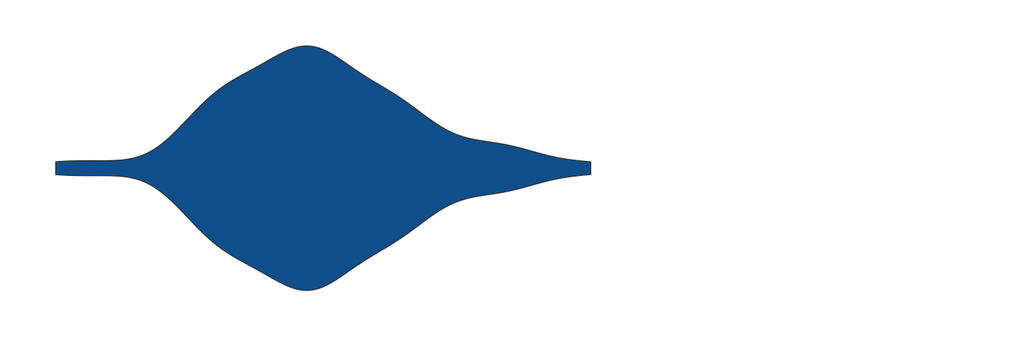

Gentoo

3950

5092.44

6300

[figure not shown]

To create this table, let us begin with the basics. Let’s compute the numeric values first.

```r
filtered_penguins <- palmerpenguins::penguins |>
    filter(!is.na(sex))

penguin_weights <- filtered_penguins |>
  group_by(species) |>
  summarise(
    Min = min(body_mass_g),
    Mean = mean(body_mass_g) |> round(digits = 2),
    Max = max(body_mass_g)
  ) |>
  mutate(species = as.character(species)) |>
  rename(Species = species)

penguin_weights |>
  gt() |>
  tab_spanner(
    label = 'Penguin\'s Weight',
    columns = -Species
  )
```

| Species | Penguin's Weight Min | Penguin's Weight Mean | Penguin's Weight Max |
| --- | --- | --- | --- |
| Adelie | 2850 | 3706.16 | 4775 |
| Chinstrap | 2700 | 3733.09 | 4800 |
| Gentoo | 3950 | 5092.44 | 6300 |

```r
plot_density_species <- function(my_species) {
  full_range <- filtered_penguins |>
    pull(body_mass_g) |>
    range()

  filtered_penguins |>
    filter(species == my_species) |>
    ggplot(aes(x = body_mass_g, y = species)) +
    geom_violin(fill = 'dodgerblue4') +
    theme_minimal() +
    scale_y_discrete(breaks = NULL) +
    scale_x_continuous(breaks = NULL) +
    labs(x = element_blank(), y = element_blank()) +
    coord_cartesian(xlim = full_range)
}
plot_density_species('Adelie')
```

[figure not shown]

Notice that I have set the coordinate system of the plot to the full range of the data (regardless of the species). This part is important. Without this trick, the three plots would not share a common x-axis. Then, our table might look something like this:

Species

Penguin's Weight

Min

Mean

Max

Distribution

Adelie

2850

3706.16

4775

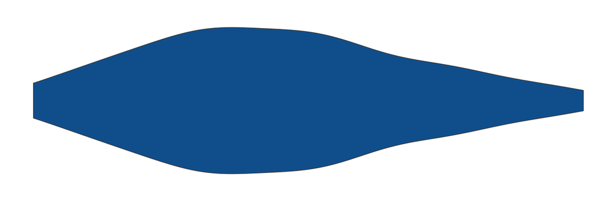

Chinstrap

2700

3733.09

4800

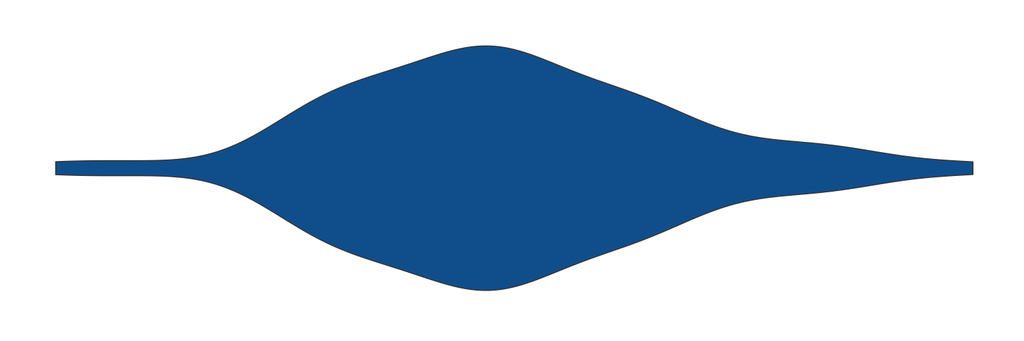

Gentoo

3950

5092.44

6300

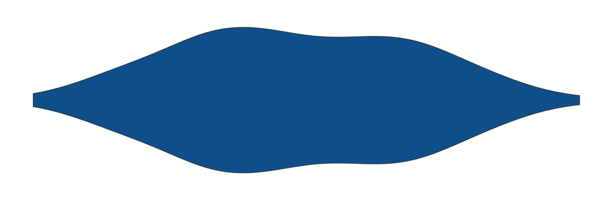

WATCH OUT: The violin plots are not using a shared axis here and are misleading

Ok, so now we have a function that creates the desired plots. Time to apply it to our table. For this to work, we need an additional column that we can target (just like before).

```r
penguin_weights |>
  mutate(Distribution = Species) |>
  gt() |>
  tab_spanner(
    label = 'Penguin\'s Weight',
    columns = -Species
  )
```

| Species | Penguin's Weight Min | Penguin's Weight Mean | Penguin's Weight Max | Penguin's Weight Distribution |
| --- | --- | --- | --- | --- |
| Adelie | 2850 | 3706.16 | 4775 | Adelie |
| Chinstrap | 2700 | 3733.09 | 4800 | Chinstrap |
| Gentoo | 3950 | 5092.44 | 6300 | Gentoo |

Next, use the `text_transform()` layer to turn the species names into ggplot images. This layer can actually target not just the data rows but everything including column labels or the table header.

So, we have to make sure that we attempt to turn only the data table cells into an image and not, say, the spanner. This is done with the helper function `cells_body()` (more on this function in Section 4.1). Here’s how that will look.

```r
penguin_weights |>
  mutate(Distribution = Species) |>
  gt() |>
  tab_spanner(
    label = 'Penguin\'s Weight',
    columns = -Species
  ) |>
  text_transform(
    locations = cells_body(columns = 'Distribution'),
    fn = #Put function here
  )
```

Finally, we need to set the `fn` argument to a function that takes a column and returns **actual images**. This is not our `plot_density_species()` function. This one takes only one species name and returns **one ggplot object**.

But we can wrap it in `map()` such that a column is turned into a list of ggplot objects. The conversion to images is performed by `ggplot_image()`. We can use it to also specify the height and width (indirectly via aspect ratio) of the image.

Species

Penguin's Weight

Min

Mean

Max

Distribution

Adelie

2850

3706.16

4775

[figure not shown]

Chinstrap

2700

3733.09

4800

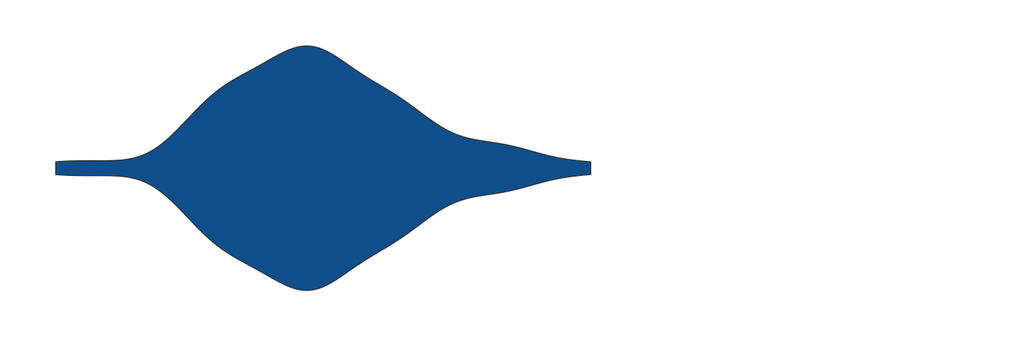

Gentoo

3950

5092.44

6300

[figure not shown]

```r
penguin_weights |>
  mutate(Distribution = Species) |>
  gt() |>
  tab_spanner(
    label = 'Penguin\'s Weight',
    columns = -Species
  ) |>
  text_transform(
    locations = cells_body(columns = 'Distribution'),
    fn = function(column) {
      map(column, plot_density_species) |>
        ggplot_image(height = px(50), aspect_ratio = 3)
    }
  )
```

We can take this up a notch. What if our plot depends on two or more variables? For example, we could label the mean weight of each species with a white line and the maximum with a red dot.

Yeah, I know. Totally arbitrary example. But it’s as good as any example, I suppose.

So first you will need a new function that depends on three arguments. But you have to make sure that all numeric variables are understood as characters. Because that’s how they will come in (you’ll see why in a sec). To use them as actual numbers, convert them from text to number via `parse_number()`.

```r
plot_density_species_with_mean <- function(my_species, my_mean, my_max) {
  full_range <- filtered_penguins |>
    pull(body_mass_g) |>
    range()

  filtered_penguins |>
    filter(species == my_species) |>
    ggplot(aes(x = body_mass_g, y = species)) +
    geom_violin(fill = 'dodgerblue4') +
    geom_vline(
      xintercept = parse_number(my_mean), # Parse number
      color = 'white',
      linewidth = 3
    ) +
    annotate(
      'point',
      x = parse_number(my_max), # Parse number
      y = 1,
      color = 'red',
      size = 25 ## Needs to be large since the image is small
    ) +
    theme_minimal() +
    scale_y_discrete(breaks = NULL) +
    scale_x_continuous(breaks = NULL) +
    labs(x = element_blank(), y = element_blank()) +
    coord_cartesian(xlim = full_range)
}
plot_density_species_with_mean('Adelie', '3700', '4775')
```

[figure not shown]

Next, we have to create a new column in our tibble that contains all the data. In this case, this means collecting `Species`, `Mean` and `Max` in a vector and wrapping that vector in a list.

```r
penguins_new <- penguin_weights |>
  group_by(Species) |>
  mutate(Distribution = list(c(Species, Mean, Max))) |>
  ungroup()
penguins_new
## # A tibble: 3 × 5
##   Species     Min  Mean   Max Distribution
##   <chr>     <int> <dbl> <int> <list>
## 1 Adelie     2850 3706.  4775 <chr [3]>
## 2 Chinstrap  2700 3733.  4800 <chr [3]>
## 3 Gentoo     3950 5092.  6300 <chr [3]>
```

Now comes the hard part. It requires a little bit of hacking. In principle, you have to write a function that transforms our table column `Distribution` into a ggplot. But take a look how `Distribution` looks in the table.

```r
penguins_new |>
  gt()
```

| Species | Min | Mean | Max | Distribution |
| --- | --- | --- | --- | --- |
| Adelie | 2850 | 3706.16 | 4775 | Adelie, 3706.16, 4775 |
| Chinstrap | 2700 | 3733.09 | 4800 | Chinstrap, 3733.09, 4800 |
| Gentoo | 3950 | 5092.44 | 6300 | Gentoo, 5092.44, 6300 |

Our beautiful list of arguments for `plot_density_species_with_mean()` is saved as a text. This means that this extra function `fn` that we’re going to pass to `text_transform()` needs to do a couple of things.

1. Split the texts into separate arguments with `str_split_1()` (better output than `str_split()`)
2. Pass the lists of arguments to `plot_density_species_with_mean()` and make sure that the arguments are placed correctly.
3. Convert ggplot objects to images with `ggplot_image()`.

And task 1 and 2 need to be wrapped in `map()` because they don’t work on whole columns.

Species

Min

Mean

Max

Distribution

Adelie

2850

3706.16

4775

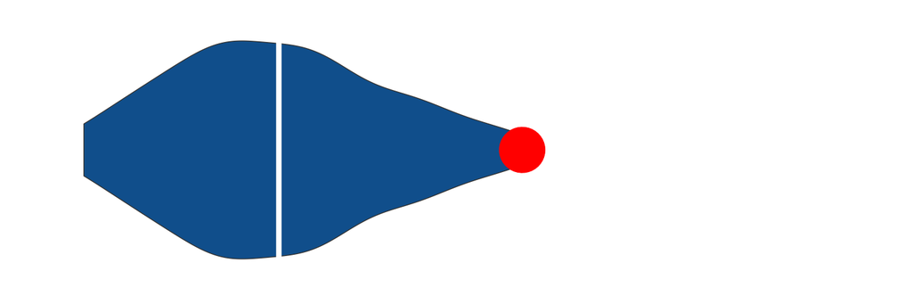

Chinstrap

2700

3733.09

4800

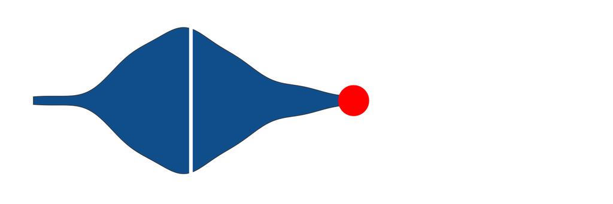

Gentoo

3950

5092.44

6300

[figure not shown]

```r
penguins_new |>
  gt() |>
  text_transform(
    locations = cells_body(columns = 'Distribution'),
    fn = function(column) {
      map(column, ~str_split_1(., ', ')) |>
        map(~plot_density_species_with_mean(.[1], .[2], .[3])) |>
        ggplot_image(height = px(50), aspect_ratio = 3)
    }
  )
```

## 2.7 Summary

Sweet! We’ve learned a lot of fancy table elements. Some of them were quite easy to implement. Some of them not so much.

In the next chapter, we’re going to take a breather. We’re going to learn about the two families of `sub_*` and `fmt_*`. They’re super easy to learn and crucial for formatting the data in your table.

[^1]: You can also get similar results with the `gt::data_color()` function. Currently, I prefer the `gtExtras::gt_color_rows()` function because it allows me to set `domain`.
[^2]: Thank you, [Brani](https://fosstodon.org/@gd047), for pointing this out to me.
[^3]: This is the current list (November 12, 2022). The British change PMs quite often recently.